# Hackathon2-Sberbank Russian Housing Market Data Analysis and Visuvalization

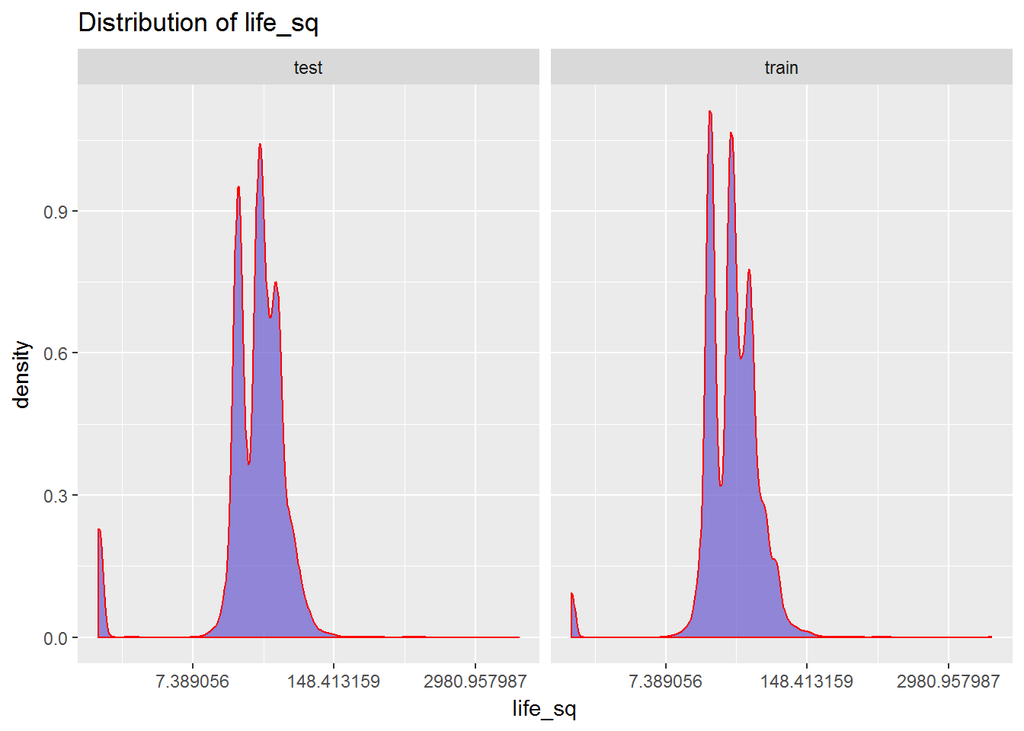

```r
all_data %>%
    ggplot(aes(x=life_sq)) +
    geom_density(color='red', fill='slateblue3', alpha=0.7) +
    facet_wrap(~as.factor(dataset)) +
    scale_x_continuous(trans='log') +
    ggtitle('Distribution of life_sq')
```

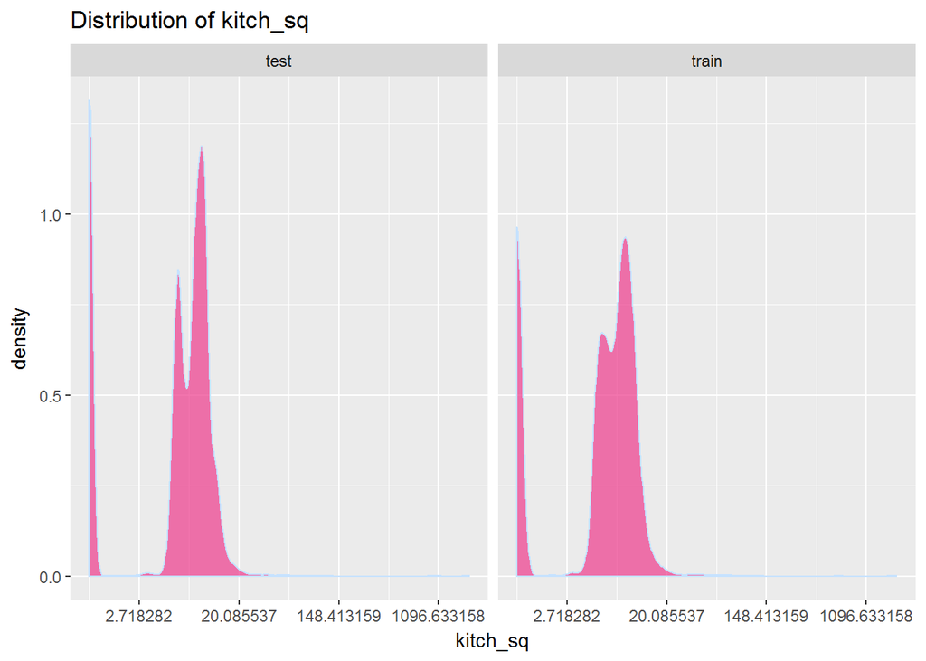

```r
all_data %>%
    ggplot(aes(x=kitch_sq)) +
    geom_density(color='slategray1', fill='violetred2', alpha=0.7) +
    facet_wrap(~as.factor(dataset)) +
    scale_x_continuous(trans='log') +
    ggtitle('Distribution of kitch_sq')
```

It seems that the distributions of the three area features are distributing similarly between the train and test sets. What about the number of rooms

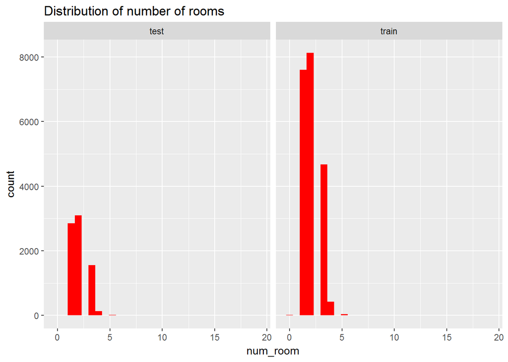

```r
all_data %>%
    ggplot(aes(x=num_room)) +
    geom_histogram(fill='red') +
    facet_wrap(~dataset) +
    ggtitle('Distribution of number of rooms')
```

floor and max_floor

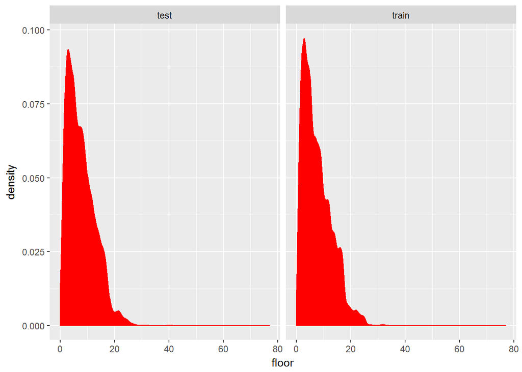

```r
all_data %>%
    ggplot(aes(x=floor)) +
    geom_density(color='red', fill='red') +
    facet_wrap(~dataset)
```

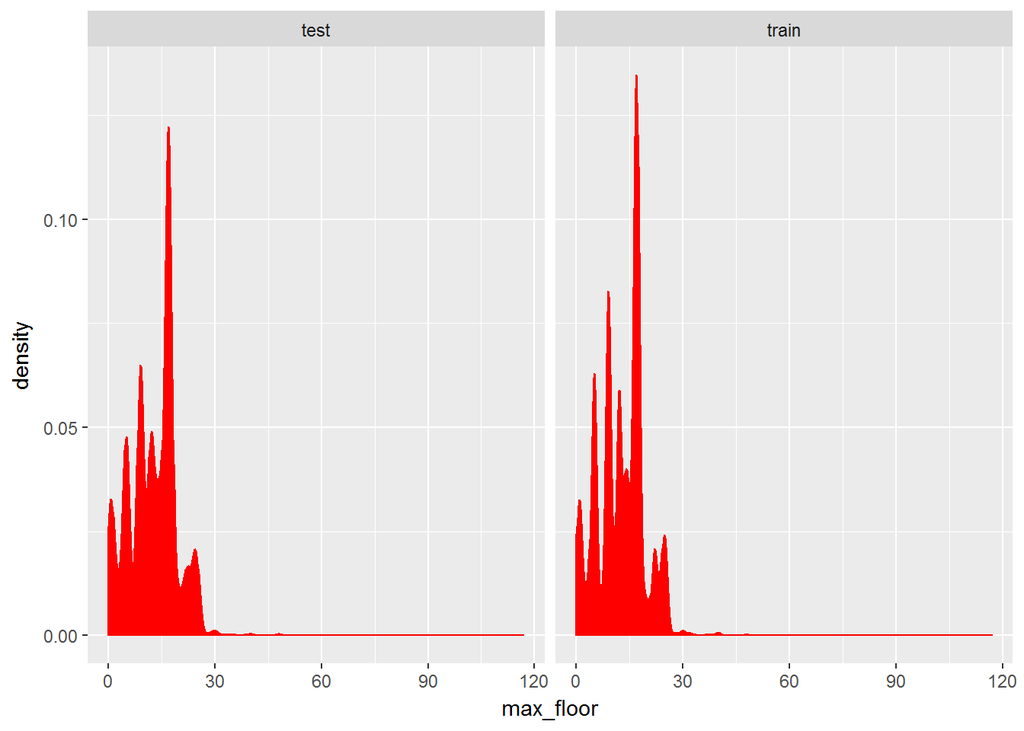

```r
all_data %>%
    ggplot(aes(x=max_floor)) +
    geom_density(color='red', fill='red') +
    facet_wrap(~dataset)
```

the floor and max_floor data to check where floor is greater than max_floor.

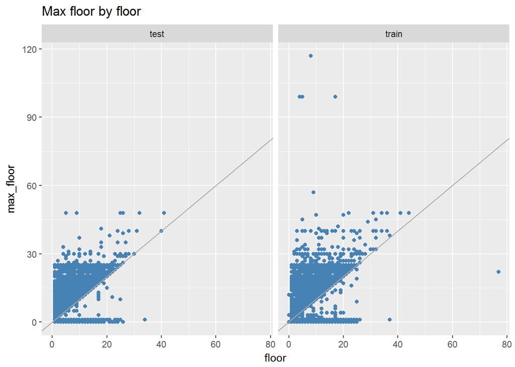

```r
all_data %>%
    ggplot(aes(x=floor, y=max_floor)) +
    geom_point(color='steelblue') +
    geom_abline(intercept=0, slope=1, color='darkgrey') +
    facet_wrap(~dataset) +
    ggtitle('Max floor by floor')
```

Number of transactions by day

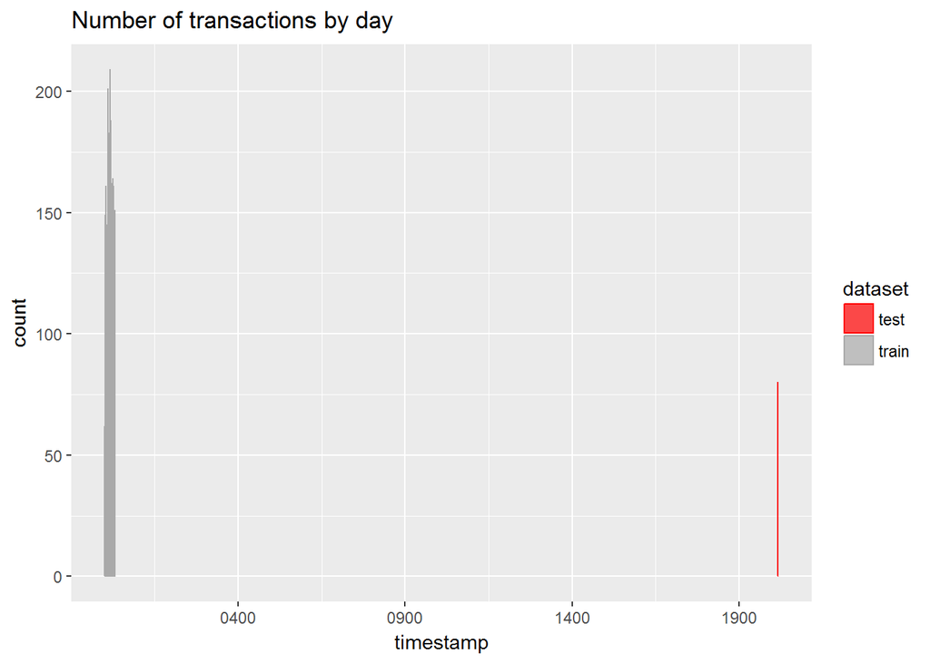

```r
all_data %>%
    ggplot(aes(x=timestamp, fill=dataset, color=dataset)) +
    geom_bar(alpha=0.7) +
    scale_fill_manual(values=c('red', 'darkgrey')) +
    scale_color_manual(values=c('red', 'darkgrey')) +
    ggtitle('Number of transactions by day')
```

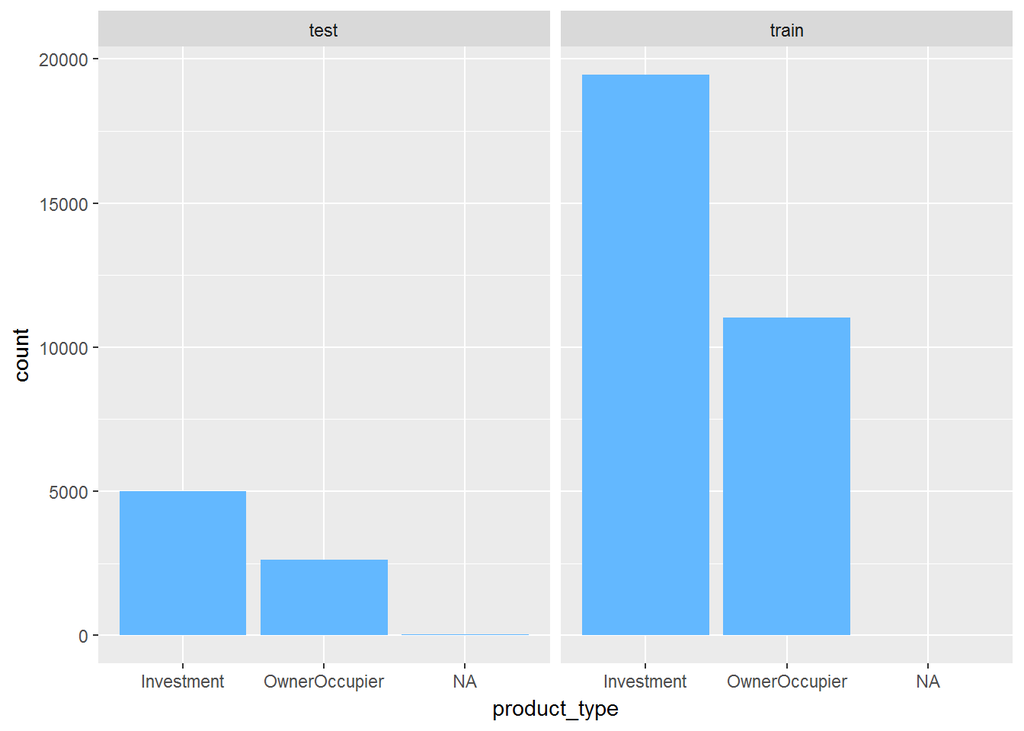

```r
ggplot(aes(x=product_type),data=all_data) +
    geom_bar(fill='steelblue1') +
    facet_grid(~dataset)
```

ales counts vary by home state across the train and test sets

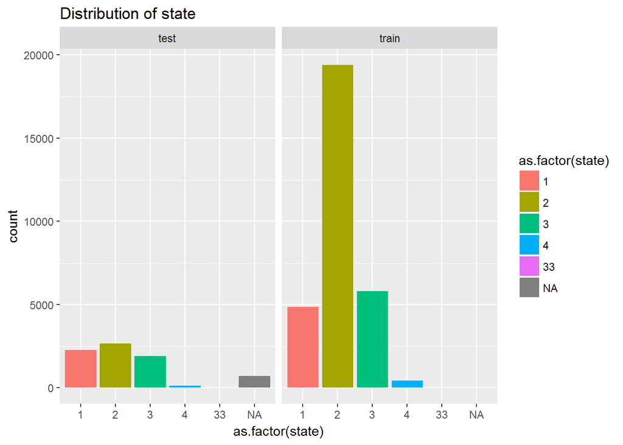

```r
all_data %>%
    ggplot(aes(x=as.factor(state), fill=as.factor(state))) +
    geom_bar() +
    facet_wrap(~dataset) +
    ggtitle('Distribution of state')
```

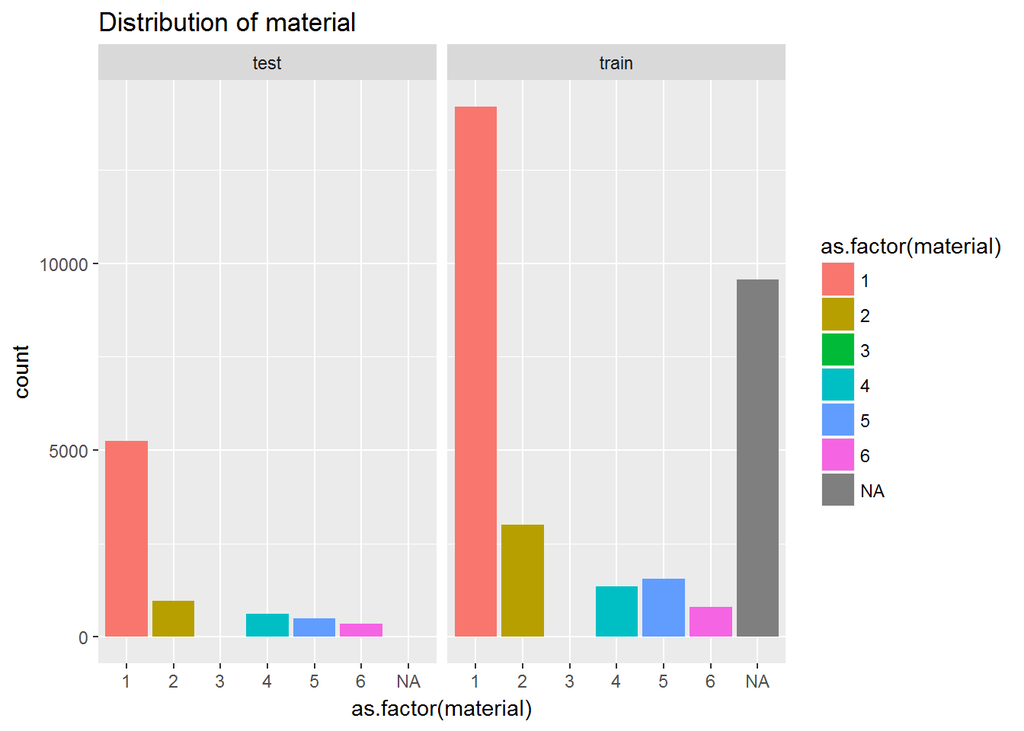

```r
all_data %>%
    ggplot(aes(x=as.factor(material), fill=as.factor(material))) +
    geom_bar() +
    facet_wrap(~dataset) +
    ggtitle('Distribution of material')
```

The distributions of material seem mostly evenly distributed across test and train. The exception is the NAs. train.csv has a large number of missing values whereas test does not